# Multivariate linear regression on speed dating data

An analysis with multivariate linear regression on data from a speed dating experiment from Columbia Business School

José Benardi de Souza Nunes

29/07/2018

> This report contains regression models created based on data describing 5000 speed dates of 4 minutes of duration involving 310 american young adults. The original data were collected by Columbia Business School professors. Further information and the data itself can be found in this [report repository](https://github.com/Benardi/speed-dating_analysis).

# Data Overview

## The variables

```
The response variable is the variable that you are interesting in making measurements and conclusions on.

A predictor variable is a variable used in regression to predict another variable.

Our response variable will be "like", we want to study how well the predictor variables can help predict its behavior and how they impact it.
```

- **iid** : id of the participant p1 in the date
- **gender** : gender of p1, 0 = woman
- **order** : of the several dates in the night, this was the nth, according to this variable
- **pid** : id of participant p2
- **int_corr** : correlation between the interests of p1 and p2
- **samerace** : Are p1 and p2 of the same race?
- **age_o** : Age of p2
- **age** : Age of p1
- **field** : field of study of p1
- **race** : race of p1. The code is Black/African American=1; European/Caucasian-American=2; Latino/Hispanic American=3; Asian/Pacific Islander/Asian-American=4; Native American=5; Other=6
- **from** : from where p1 comes from
- **career** : what career p1 wants to follow sports, tvsports, exercise, dining, museums, art, hiking, gaming, clubbing, reading, tv, theater, movies, concerts, music, shopping, yoga : From 1 to 10, how interested p1 is in each one of these activities$
- **attr** : how attractive p1 thinks p2 is
- **sinc** : how sincere p1 thinks p2 is
- **intel** : how smart p1 thinks p2 is
- **fun** : how fun p1 thinks p2 is
- **amb** : how ambitious p1 thinks p2 is
- **shar** : how much p1 believes they both (p1 and p2) share the same interests and hobbies
- **like** : in general, how much does p1 likes p2?
- **prob** : how probable p1 thinks it’s that p2 will want to meet again with p- (scale 1-10)
- **attr3_s** : how attractive p1 believes itself
- **sinc3_s** : how sincere p1 believes itself
- **intel3_s** : how smart p1 believes itself
- **fun3_s** : how fun p1 believes itself
- **amb3_s** : how ambitious p1 believes itself

```r
data <- read_csv(here("data/speed-dating.csv"),
                 progress = FALSE,
                 col_types =cols(.default = col_integer(),
                                 int_corr = col_double(),
                                 field = col_character(),
                                 from = col_character(),
                                 career = col_character(),
                                 attr = col_double(),
                                 samerace = col_character(),
                                 sinc = col_double(),
                                 intel = col_double(),
                                 fun = col_double(),
                                 amb = col_double(),
                                 shar = col_double(),
                                 like = col_double(),
                                 prob = col_double(),
                                 match_es = col_double(),
                                 attr3_s = col_double(),
                                 sinc3_s = col_double(),
                                 intel3_s = col_double(),
                                 fun3_s = col_double(),
                                 amb3_s = col_double())) %>%
  mutate(from = as.numeric(factor(from)),
         gender = as.numeric(factor(gender)),
         samerace = as.numeric(factor(samerace)))
data %>%
  glimpse()
```

```
Observations: 4,918
Variables: 43
$ iid      <int> 1, 1, 1, 1, 1, 1, 1, 1, 1, 1, 2, 2, 2, 2, 2, 2, 2, 2, 2, 2, 3, 3, 3, 3,...
$ gender   <dbl> 1, 1, 1, 1, 1, 1, 1, 1, 1, 1, 1, 1, 1, 1, 1, 1, 1, 1, 1, 1, 1, 1, 1, 1,...
$ order    <int> 4, 3, 10, 5, 7, 6, 1, 2, 8, 9, 10, 9, 6, 1, 3, 2, 7, 8, 4, 5, 6, 5, 2, ...
$ pid      <int> 11, 12, 13, 14, 15, 16, 17, 18, 19, 20, 11, 12, 13, 14, 15, 16, 17, 18,...
$ int_corr <dbl> 0.14, 0.54, 0.16, 0.61, 0.21, 0.25, 0.34, 0.50, 0.28, -0.36, 0.29, 0.18...
$ samerace <dbl> 1, 1, 2, 1, 1, 1, 1, 1, 1, 1, 2, 2, 1, 2, 1, 2, 2, 2, 2, 2, 2, 2, 1, 2,...
$ age_o    <int> 27, 22, 22, 23, 24, 25, 30, 27, 28, 24, 27, 22, 22, 23, 24, 25, 30, 27,...
$ age      <int> 21, 21, 21, 21, 21, 21, 21, 21, 21, 21, 24, 24, 24, 24, 24, 24, 24, 24,...
$ field    <chr> "Law", "Law", "Law", "Law", "Law", "Law", "Law", "Law", "Law", "Law", "...
$ race     <int> 4, 4, 4, 4, 4, 4, 4, 4, 4, 4, 2, 2, 2, 2, 2, 2, 2, 2, 2, 2, 2, 2, 2, 2,...
$ from     <dbl> 34, 34, 34, 34, 34, 34, 34, 34, 34, 34, 2, 2, 2, 2, 2, 2, 2, 2, 2, 2, 4...
$ career   <chr> "lawyer", "lawyer", "lawyer", "lawyer", "lawyer", "lawyer", "lawyer", "...
$ sports   <int> 9, 9, 9, 9, 9, 9, 9, 9, 9, 9, 3, 3, 3, 3, 3, 3, 3, 3, 3, 3, 3, 3, 3, 3,...
```

[output cut: 30 more lines]

## Data exploration

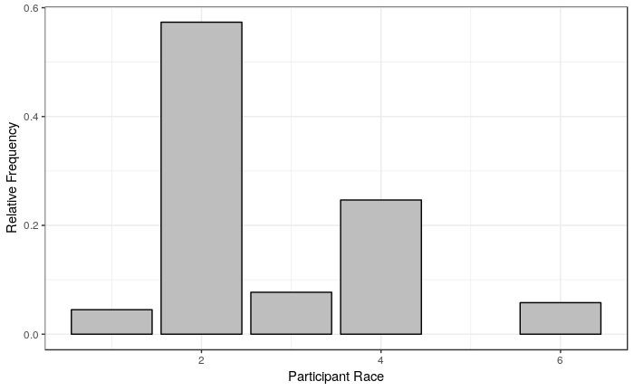

```r
data %>%
  na.omit(race) %>%
  ggplot(aes(race, ..prop..)) +
    geom_bar(color = "black",
           fill = "grey") +
  labs(x= "Participant Race",
       y = "Relative Frequency")
```

- Most of the participants are white (code = 2)
- There were no Native Americans involved (code = 5)

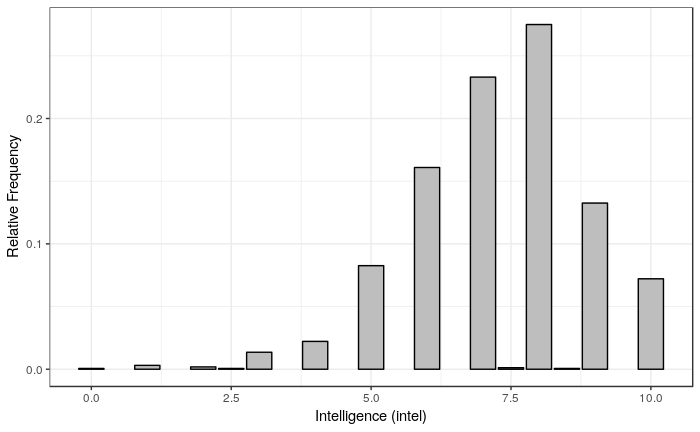

```r
data %>%
  na.omit(intel) %>%
  ggplot(aes(intel, ..prop..)) +
  geom_bar(color = "black",
           fill = "grey") +
  labs(x= "Intelligence (intel)",
       y = "Relative Frequency")
```

- Most of the time P1 gave P2 a score around 7.5 for intelligence.

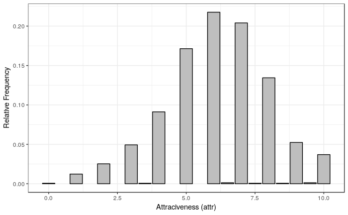

```r
data %>%
  na.omit(attr) %>%
  ggplot(aes(attr, ..prop..)) +
  geom_bar(color = "black",
           fill = "grey") +
  labs(x= "Attraciveness (attr)",
       y = "Relative Frequency")
```

- Most of the time P1 gave P2 a score around 6 for attractiveness.

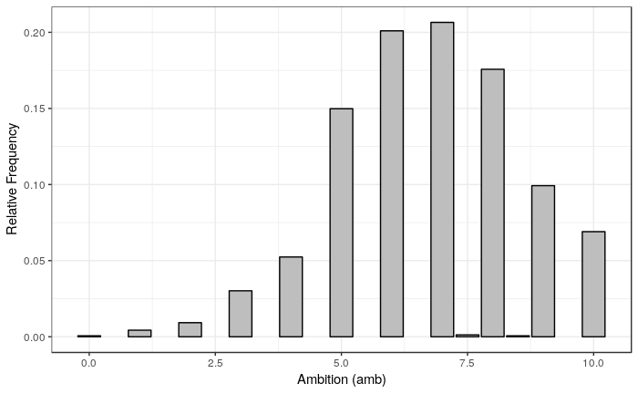

```r
data %>%
  na.omit(amb) %>%
  ggplot(aes(amb, ..prop..)) +
  geom_bar(color = "black",
           fill = "grey") +
  labs(x= "Ambition (amb)",
       y = "Relative Frequency")
```

- Similar to intelligence

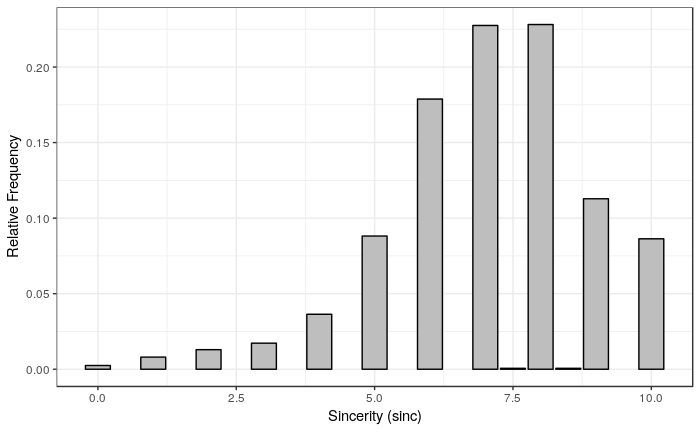

```r
data %>%
  na.omit(sinc) %>%
  ggplot(aes(sinc, ..prop..)) +
  geom_bar(color = "black",
           fill = "grey") +
  labs(x= "Sincerity (sinc)",
       y = "Relative Frequency")
```

- Similar to intelligence

## Choosing promising predictor variables

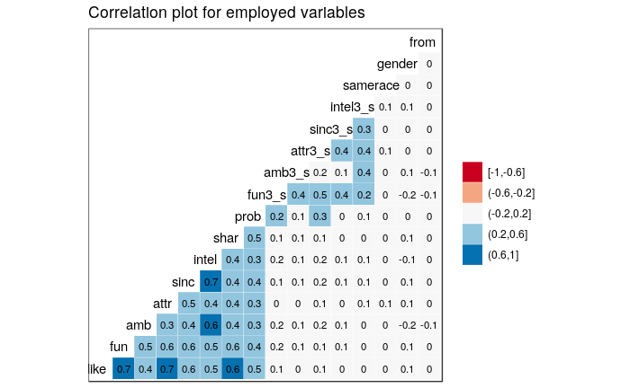

```r
require(GGally)
data %>%
  select(like,fun,amb,attr,
         sinc,intel,shar,prob,
         fun3_s,amb3_s,attr3_s,
         sinc3_s,intel3_s,samerace,
         gender,from) %>%
  na.omit() %>%
  ggcorr(palette = "RdBu", label = TRUE,
       hjust = 0.75, label_size = 3, nbreaks = 5) +
  ggtitle("Correlation plot for employed variables")
```

- What a person (p1) believes about herself/himself doesn’t show promising results in terms of correlation
- Among what p1 thinks about p2 how *ambitious* p1 thinks p2 is shows the weakest correlation with how much p1 likes p2.
- Intelligence has interesting interactions with sincerity and ambition.

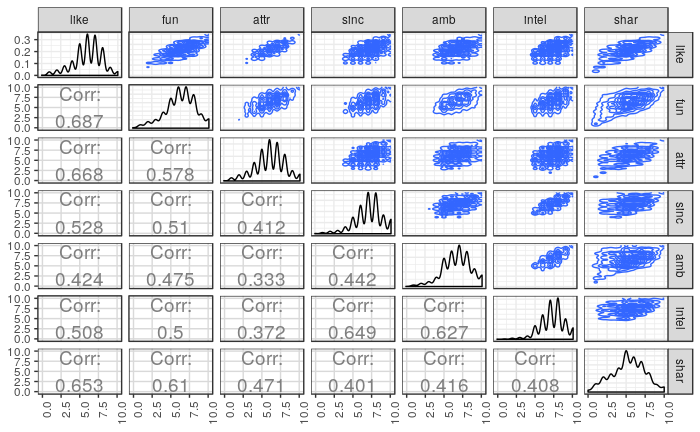

```r
data %>%
  select(like,fun,attr,sinc,
         amb,intel,shar) %>%
  na.omit() %>%
  ggpairs(upper = list(continuous = "density"),
        lower = list(continuous = wrap("cor", size=5)),
        axisLabels = 'show',progress = F) +
  theme(axis.text.x = element_text(angle = 90, hjust = 1))
```

Regarding the relationship with the response variable “**like**”:

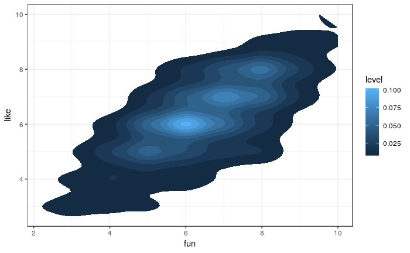

```r
data %>%
  na.omit(fun, like) %>%
  ggplot(aes(fun, like)) +
  stat_density2d(aes(fill = ..level..),
                 geom = "polygon")
```

- Intuition would suggest a positive interaction between being seen as fun and being liked, that interaction being of considerable magnitude.

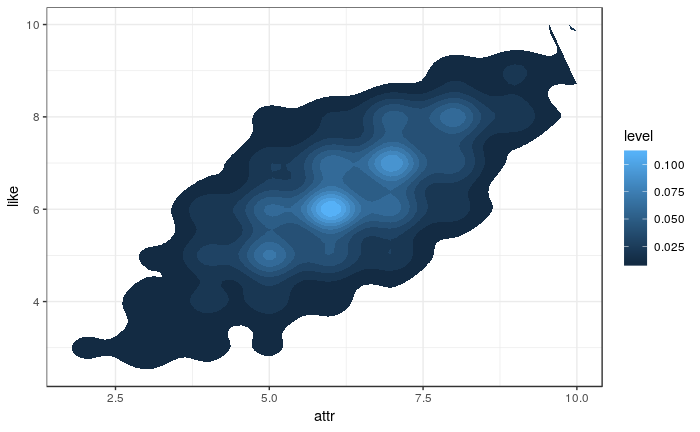

```r
data %>%
  na.omit(attr, like) %>%
  ggplot(aes(attr, like)) +
  stat_density2d(aes(fill = ..level..),
                 geom = "polygon")
```

- Intuition would suggest a positive interaction between being seen as attractive and being liked (no surprise there), that interaction being of considerable magnitude.

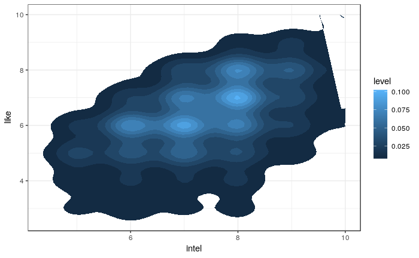

```r
data %>%
  na.omit(intel, like) %>%
  ggplot(aes(intel, like)) +
  stat_density2d(aes(fill = ..level..),
                 geom = "polygon")
```

- Intuition would suggest a positive interaction between being seen as intelligent and being liked (although not so clear).

## Splitting Data for Cross Validation

```r
data %>%  # Keep only promising predictor variables and response variable
  select(fun, prob, order, amb,
         attr, sinc, prob, shar,
         intel, like, gender, samerace) %>%
  na.omit() -> data  # remove NAs
data %>% ## Put numeric predictor variables on same scale
   mutate_at(.vars = vars(fun, prob, order,attr,
                          sinc, prob, shar,intel),
             .funs = funs(as.numeric(scale(.)))) -> data_scaled
data_scaled %>%
  glimpse()
```

```
Observations: 4,101
Variables: 11
$ fun      <dbl> 0.3673163, 0.8696052, 0.3673163, 0.3673163, -1.1395502, -1.1395502, -0....
$ prob     <dbl> 0.44246160, -0.01644963, 0.44246160, 0.44246160, -0.01644963, -0.016449...
$ order    <dbl> -0.90758631, -1.08582650, -0.72934613, -0.37286577, -0.55110595, -1.442...
$ amb      <dbl> 6, 5, 6, 6, 6, 6, 5, 8, 10, 6, 9, 3, 5, 7, 6, 7, 9, 4, 9, 8, 9, 9, 9, 7...
$ attr     <dbl> -0.0256121, 0.4905314, 0.4905314, -0.5417556, -1.0578991, 0.4905314, -1...
$ sinc     <dbl> 1.09093408, 0.53812046, -0.56750679, -0.56750679, 1.09093408, -0.567506...
$ shar     <dbl> -0.1395212, 0.3235922, 1.2498190, 0.3235922, -0.6026347, 0.7867056, 0.3...
$ intel    <dbl> -0.1541995, -0.1541995, 0.4728427, -0.1541995, -0.1541995, -0.1541995, ...
$ like     <dbl> 7, 7, 7, 6, 6, 6, 6, 7, 6, 6, 7, 6, 7, 8, 6, 8, 5, 5, 8, 8, 8, 8, 8, 8,...
$ gender   <dbl> 1, 1, 1, 1, 1, 1, 1, 1, 1, 1, 1, 1, 1, 1, 1, 1, 1, 1, 1, 1, 1, 1, 1, 1,...
$ samerace <dbl> 1, 1, 1, 1, 1, 1, 1, 1, 1, 2, 2, 1, 2, 1, 2, 2, 2, 2, 2, 2, 2, 1, 2, 2,...
```

- Selecting promising predictors, filtering invalid numbers and putting the variables on appropriate scale

#### For the sake of simplicity we’ll follow the (80/20) thumb rule (based on Pareto’s principle) and put 80% of our dataset in the training set and 20% in the test set.

```r
set.seed(101) # We set the set for reason of reproducibility
## Adding surrogate key to dataframe
data_scaled$id <- 1:nrow(data_scaled)
data_scaled %>%
  dplyr::sample_frac(.8) -> training
training %>%
  glimpse()
```

```
Observations: 3,281
Variables: 12
$ fun      <dbl> 0.3673163, 0.3673163, -0.1349725, 0.8696052, -0.6372614, -2.1441279, -0...
$ prob     <dbl> 0.90137283, 2.27810651, -0.01644963, 0.90137283, 0.90137283, 0.44246160...
$ order    <dbl> 0.16185478, -0.55110595, -0.90758631, 0.87481550, -0.19462559, -1.44230...
$ amb      <dbl> 8, 10, 6, 7, 4, 7, 6, 2, 9, 6, 6, 8, 7, 6, 8, 6, 8, 9, 5, 6, 6, 4, 9, 4...
$ attr     <dbl> 1.5228184, -1.5740426, -0.0256121, 0.4905314, -2.0901862, -0.5417556, -...
$ sinc     <dbl> 0.53812046, 1.64374770, -0.01469317, 0.53812046, -2.22594767, -0.567506...
$ shar     <dbl> 1.2498190, -0.1395212, -0.1395212, 1.2498190, -1.5288615, -1.0657481, 0...
$ intel    <dbl> 1.0998849, -0.1541995, -0.7812416, 0.4728427, -2.0353260, -0.1541995, -...
$ like     <dbl> 8, 4, 6, 8, 1, 4, 6, 3, 9, 8, 6, 7, 8, 5, 6, 5, 7, 9, 6, 5, 6, 7, 5, 4,...
$ gender   <dbl> 2, 2, 2, 2, 1, 2, 2, 2, 1, 2, 1, 2, 2, 2, 1, 2, 1, 1, 1, 2, 2, 2, 1, 2,...
$ samerace <dbl> 1, 2, 1, 2, 2, 2, 1, 1, 2, 2, 1, 2, 1, 1, 1, 1, 2, 2, 1, 2, 2, 1, 1, 2,...
$ id       <int> 1527, 180, 2909, 2696, 1024, 1230, 2396, 1366, 2546, 2234, 3600, 2892, ...
```

- Randomly selecting the **training data**

```r
dplyr::anti_join(data_scaled,
                 training,
                 by = 'id') -> testing
testing %>%
  glimpse()
```

```
Observations: 820
Variables: 12
$ fun      <dbl> -0.1349725, -0.1349725, -1.6418391, 0.3673163, 0.8696052, 1.8741829, 1....
$ prob     <dbl> 0.90137283, 1.36028406, -0.01644963, 0.90137283, -1.85209455, 2.2781065...
$ order    <dbl> -0.55110595, -1.44230686, -1.26406668, -1.44230686, -0.01638541, -0.907...
$ amb      <dbl> 3, 5, 6, 9, 6, 7, 8, 5, 4, 3, 2, 8, 7, 7, 6, 6, 1, 10, 10, 10, 9, 9, 4,...
$ attr     <dbl> -0.5417556, 0.4905314, 1.0066749, 1.0066749, -1.0578991, 1.0066749, -0....
$ sinc     <dbl> 0.53812046, 1.09093408, -0.01469317, -0.01469317, -0.01469317, 1.643747...
$ shar     <dbl> -0.6026347, 0.7867056, -1.5288615, 0.7867056, 0.7867056, 2.1760458, 1.7...
$ intel    <dbl> 1.0998849, -0.1541995, 0.4728427, 1.0998849, 0.4728427, -0.1541995, 0.4...
$ like     <dbl> 6, 7, 6, 8, 4, 8, 7, 6, 7, 6, 9, 5, 7, 6, 8, 9, 1, 10, 10, 10, 5, 9, 5,...
$ gender   <dbl> 1, 1, 1, 1, 1, 1, 1, 1, 1, 1, 1, 1, 2, 2, 2, 2, 2, 2, 2, 2, 2, 2, 2, 2,...
$ samerace <dbl> 1, 2, 2, 2, 1, 2, 1, 2, 1, 2, 1, 1, 1, 1, 2, 2, 2, 1, 1, 1, 1, 1, 1, 1,...
$ id       <int> 12, 13, 15, 27, 30, 31, 32, 39, 42, 50, 51, 62, 96, 98, 101, 107, 109, ...
```

- The rest of the data will be the **testing data** (Disjoint sets)

# Our questions

#### How does intelligence impact on how much P1 likes P2 (like) ?

- Positive or negative impact ?
- Is it significant ?
- Is it relevant ?

#### How does intelligence interact with other characteristics (predictors) ?

- Positive or negative impact ?
- Is it significant ?
- Is it relevant ?

# Applying Linear Regression Model

Our evaluation of the regression can be divided as follow:

- Train the model with the training data
  - Observe the R² and adjusted R²
- Analyze the training residue
- Use the test data to cross validate our model.

```
Our response variable is the variable "like" (How much participant 1 liked participant 2).
```

## Predictors estimates (C.I)

In this model we will include the main predictor variables (according to what we’ve seen in terms of correlation and some tweaking with the predictors that is not here). We’ll also try to observe the effect of intelligence in sincerity. **For the sake of simplicity we’ll use the thumb rule of alpha = 0.05 (95% confidence intervals).**

- **sinc * intel** refers to the interaction between sincerity and intelligence.
- **amb * intel** refers to the interaction between ambition and intelligence.

```r
mod <- lm(like ~ fun + attr + shar + sinc + prob + intel + amb + sinc * intel + amb * intel,
          data = training)
glance(mod)
```

|  | r.squared | adj.r.squared | sigma | statistic | p.value | df | logLik | AIC | BIC | deviance | df.residual |
| --- | --- | --- | --- | --- | --- | --- | --- | --- | --- | --- | --- |
| 1 | 0.6802819 | 0.6794022 | 1.048538 | 773.321 | 0 | 10 | -4806.04 | 9634.08 | 9701.135 | 3596.245 | 3271 |

- We got a modest 0.68 R² and adjusted R² approximately. This means that this model explain approximately 68% of the response variable variability.

```r
tidy(mod,
     conf.int = TRUE,
     conf.level = 0.95)
```

| term | estimate | std.error | statistic | p.value | conf.low | conf.high |
| --- | --- | --- | --- | --- | --- | --- |
| (Intercept) | 6.234966377 | 0.092183545 | 67.636435 | 0.000000e+00 | 6.05422307 | 6.415709685 |
| fun | 0.428505894 | 0.027302875 | 15.694534 | 1.415801e-53 | 0.37497343 | 0.482038355 |
| attr | 0.623307792 | 0.023103110 | 26.979389 | 6.344680e-145 | 0.57800977 | 0.668605816 |
| shar | 0.410154736 | 0.024944893 | 16.442433 | 1.973528e-58 | 0.36124555 | 0.459063926 |
| sinc | 0.134617499 | 0.025764526 | 5.224917 | 1.851451e-07 | 0.08410126 | 0.185133734 |
| prob | 0.259732457 | 0.021124181 | 12.295504 | 5.333190e-34 | 0.21831450 | 0.301150417 |
| intel | 0.228194636 | 0.066680762 | 3.422196 | 6.288003e-04 | 0.09745437 | 0.358934906 |
| amb | -0.027500804 | 0.013428752 | -2.047905 | 4.064903e-02 | -0.05383042 | -0.001171191 |
| sinc:intel | -0.027170176 | 0.016979662 | -1.600160 | 1.096597e-01 | -0.06046202 | 0.006121668 |
| intel:amb | -0.005364909 | 0.009282091 | -0.577985 | 5.633141e-01 | -0.02356421 | 0.012834390 |

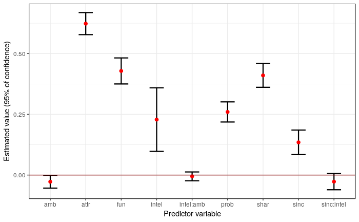

```r
tidy(mod,
     conf.int = TRUE,
     conf.level = 0.95)  %>%
  filter(term != "(Intercept)") %>%
  ggplot(aes(term, estimate, ymin = conf.low, ymax = conf.high)) +
  geom_errorbar(size = 0.8, width= 0.4) +
  geom_point(color = "red", size = 2) +
  geom_hline(yintercept = 0, colour = "darkred") +
  labs(x = "Predictor variable",
       y = "Estimated value (95% of confidence)")
```

## Residual Analysis

Let’s keep the residue data in a specific data frame

```r
mod.res <- resid(mod)
std.resid <- rstandard(mod)
like <- training$like
resid_data <- data.frame(mod.res,std.resid,like,
                       stringsAsFactors=FALSE)
resid_data %>%
  sample_n(10)
```

|  | mod.res | std.resid | like |
| --- | --- | --- | --- |
| 1545 | 0.08123023 | 0.07751396 | 6 |
| 3142 | 0.25581921 | 0.24474928 | 7 |
| 1992 | -1.28544191 | -1.22659975 | 6 |
| 3056 | -0.16314262 | -0.15583775 | 6 |
| 585 | -1.07398503 | -1.02509568 | 5 |
| 694 | 0.83368607 | 0.79575111 | 7 |
| 606 | 2.35734613 | 2.25078297 | 6 |
| 400 | -0.04007410 | -0.03830054 | 3 |
| 705 | -2.32437293 | -2.22559171 | 2 |
| 1156 | 0.33431414 | 0.31961504 | 6 |

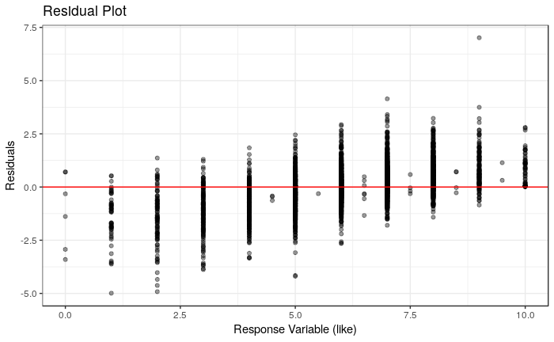

```r
resid_data %>%
  ggplot(aes(like, mod.res)) +
  geom_point(alpha = 0.4) +
  geom_hline(yintercept = 0,
             color = "red") +
  labs(x = "Response Variable (like)", y = "Residuals") +
  ggtitle("Residual Plot")
```

- There’s a clear pattern in the residuals.
- They’re not symmetrically distributed, nor they tend to cluster towards the middle of the plot.
- They’re relatively clustered around the lower single digits of the y-axis (e.g., ideally would be 0.5 or 1.5), while not ideal it could be worse.

> The model doesn’t seem to fit the data that well

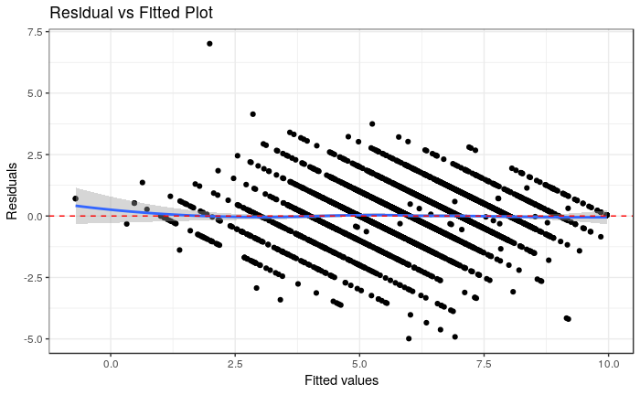

```r
mod %>%
  ggplot(aes(.fitted, .resid)) +
  geom_point() +
  stat_smooth(method="loess") +
  geom_hline(yintercept=0, col="red", linetype="dashed") +
  xlab("Fitted values") + ylab("Residuals") +
  ggtitle("Residual vs Fitted Plot")
```

- There’s no distinctive pattern in the plot, therefore this suggests that there wasn’t non-linear patterns in the data that couldn’t be explained by the model and were left out in the residuals.

> The data doesn’t seem to demand a non-linear regression.

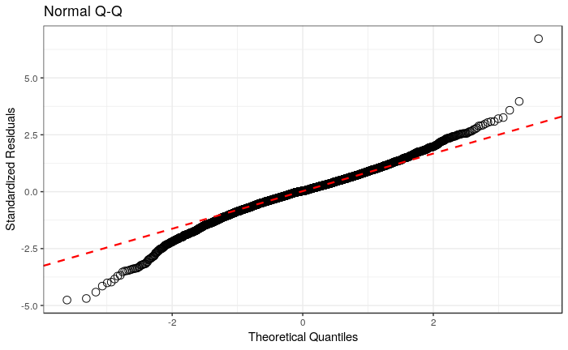

```r
y <- quantile(resid_data$std.resid[!is.na(resid_data$std.resid)], c(0.25, 0.75))
x <- qnorm(c(0.25, 0.75))
slope <- diff(y)/diff(x)
int <- y[1L] - slope * x[1L]
resid_data %>%
  ggplot(aes(sample=std.resid)) +
  stat_qq(shape=1, size=3) +      # open circles
  labs(title="Normal Q-Q",        # plot title
  x="Theoretical Quantiles",      # x-axis label
  y="Standardized Residuals") +   # y-axis label
  geom_abline(slope = slope,
              color = "red",
              size = 0.8,
              intercept = int,
              linetype="dashed")  # dashed reference line
```

- There’s some considerable deviation from the normal distribution on the left side of the qq plot, otherwise the the standardized residuals are not that far way from the normal distribution.

> This suggests that there would be a better combination of predictors to be found, although the current one still explains a sizable portion of the data variability .

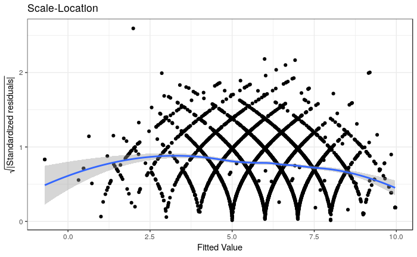

```r
mod %>%
  ggplot(aes(.fitted,
             sqrt(abs(.stdresid)))) +
  geom_point(na.rm=TRUE) +
  stat_smooth(method="loess",
              na.rm = TRUE) +
  labs(title = "Scale-Location",
       x= "Fitted Value",
       y = expression(sqrt("|Standardized residuals|")))
```

- The residuals appear to be somewhat randomly spread, however there’s a tendency in them to form a parabola.
- There’s some degree of violation on the assumption of equal variance (homoscedasticity).

> Confirmation of the qqplot results.

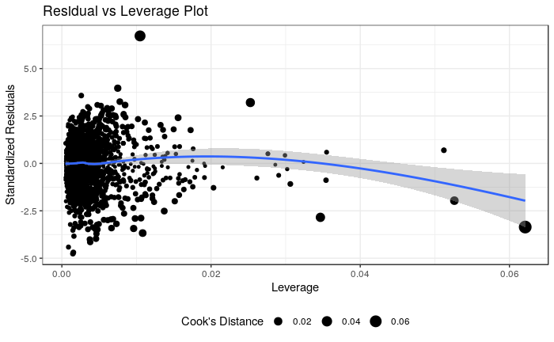

```r
mod %>%
  ggplot(aes(.hat, .stdresid)) +
  geom_point(aes(size=.cooksd), na.rm=TRUE) +
  stat_smooth(method="loess", na.rm=TRUE) +
  xlab("Leverage")+ylab("Standardized Residuals") +
  ggtitle("Residual vs Leverage Plot") +
  scale_size_continuous("Cook's Distance", range=c(1,5)) +
  theme(legend.position="bottom")
```

- All the occurrences have low values of Cook’s Distance (below 0.1).

> There are no “outliers”/extreme values who are influential cases (i.e., subjects) and would therefore have an undue influence on the regression line.

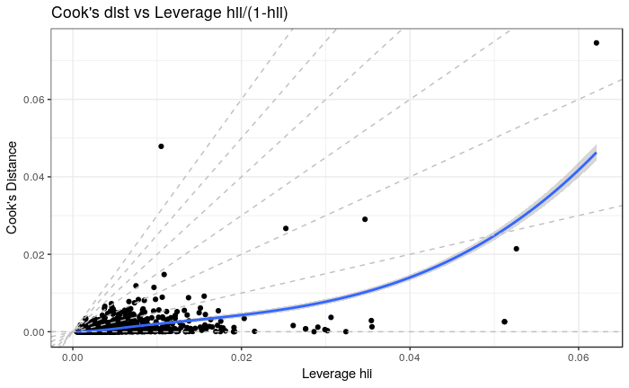

```r
mod %>%
  ggplot(aes(.hat, .cooksd)) +
  geom_point(na.rm=TRUE) +
  stat_smooth(method="loess", na.rm=TRUE) +
  xlab("Leverage hii")+ylab("Cook's Distance") +
  ggtitle("Cook's dist vs Leverage hii/(1-hii)") +
  geom_abline(slope=seq(0,3,0.5), color="gray", linetype="dashed")
```

> Plot confirms results of Residual vs Leverage Plot

## Cross Validation

### Validation Set Approach

```r
predictions <- mod %>% predict(testing)
data.frame( R2 = caret::R2(predictions, testing$like),
            RMSE = caret::RMSE(predictions, testing$like),
            MAE = caret::MAE(predictions, testing$like),
            ERR = caret::RMSE(predictions, testing$like)/
              mean(testing$like))
```

| R2 | RMSE | MAE | ERR |
| --- | --- | --- | --- |
| 0.6562164 | 1.100048 | 0.8009587 | 0.1812962 |

Now let’s talk about the results taken from the test data (the most meaningful).

> While not completely bad our model certainly left a lot of room for improvement.

# Conclusion

Let’s now gather all the information our model provided and definitely provide an answer

## How does intelligence impact on how much P1 likes P2 (like) ?

- Positive or negative impact ?

```
Intelligence has a positive impact on (like), the smarter P1 thinks P2 is the higher (like) will be.
```

- Is it significant ?

```
At 95% of confidence we have evidence that the effect of intelligence on (like) is significant (C.I. exclusively above 0).
```

- Is it relevant ?

[output not shown]

## How does intelligence interact with other characteristics (predictors) ?

- Positive or negative impact ?

```
Inteligence has an interaction with Sincerity and with Ambition, at 95% of confidence we can't be sure whether the effect for either is positive or negative as both C.I.s intersect 0.
```

- Is it significant ?

```
At 95% of confidence we have evidence that it's not significant both (Inteligence * Sincerity) and (Inteligence * Ambition).
```

- Is it relevant ?

```
It's not relevant for both (Inteligence * Sincerity) and (Inteligence * Ambition).
```